# Resampling methods

## Resampling methods

Resampling methods involve repeatedly taking samples from the original data to quantify the uncertainty in parameter estimates or to choose between different candidate models.

They are computationally expensive methods.

Further reading: Chapter 5 of [ISLR](https://web.stanford.edu/~hastie/ISLR2/ISLRv2_website.pdf) (An Introduction to Statistical Learning by James, Witten, Hastie and Tibshirani).

## Some simulated data

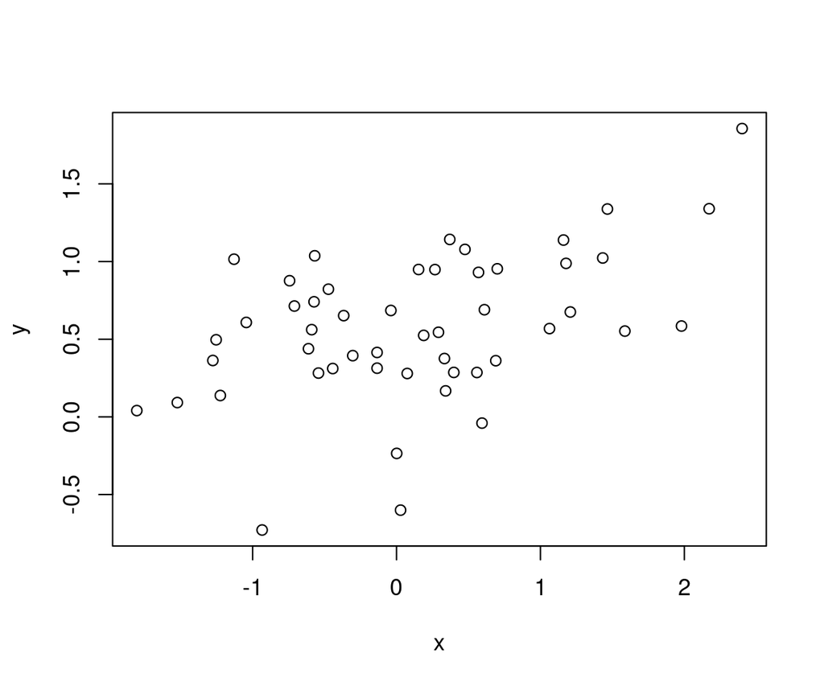

```r
plot(y ~ x)
```

## A simple linear model

Model \(Y_i = \beta_0 + \beta_1 x_i + \epsilon_i, \quad \epsilon_i \sim N(0, \sigma^2)\).

In matrix form \(Y = X \beta + \epsilon\), where \[Y = \begin{pmatrix} Y_1 \\ Y_2 \\ \vdots \\ Y_n \end{pmatrix}, \quad X = \begin{pmatrix} 1 & x_1 \\ 1 & x_2 \\ \vdots & \vdots \\ 1 & x_n \end{pmatrix}, \quad \beta = \begin{pmatrix} \beta_0 \\ \beta_1 \end{pmatrix}, \quad \epsilon = \begin{pmatrix} \epsilon_1 \\ \epsilon_2 \\ \vdots \\ \epsilon_n \end{pmatrix}.\]

See MATH2010 for details.

## Estimating the parameters

```r
mod <- lm(y ~ x)
mod
```

```
##
## Call:
## lm(formula = y ~ x)
##
## Coefficients:
## (Intercept)            x
##      0.5522       0.2332
```

## The fitted model

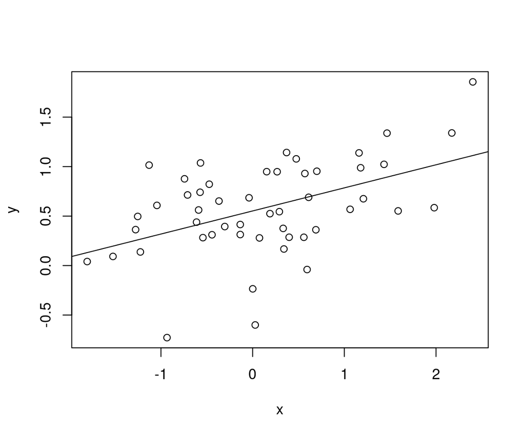

```r
plot(y ~ x)
abline(mod)
```

## Uncertainty in the estimated parameters

We can plug-in an estimate \(\hat \sigma\) of \(\sigma\) to get standard errors for each regression parameter

\[\text{s.e.}(\hat \beta_j) = \hat \sigma \sqrt{\left[(X^T X)^{-1}\right]_{jj}}\]

See MATH2010 for details.

Knowing the distribution of estimators is helpful in many ways: let’s look at some examples.

## Standard errors and hypothesis testing

```r
summary(mod)
```

```
##
## Call:
## lm(formula = y ~ x)
##
## Residuals:
##      Min       1Q   Median       3Q      Max
## -1.15907 -0.22542  0.01235  0.31168  0.74398
##
## Coefficients:
##             Estimate Std. Error t value Pr(>|t|)
## (Intercept)  0.55219    0.05979   9.235 3.21e-12 ***
## x            0.23323    0.06188   3.769 0.000449 ***
## ---
## Signif. codes:  0 '***' 0.001 '**' 0.01 '*' 0.05 '.' 0.1 ' ' 1
##
## Residual standard error: 0.4197 on 48 degrees of freedom
## Multiple R-squared:  0.2283, Adjusted R-squared:  0.2123
## F-statistic:  14.2 on 1 and 48 DF,  p-value: 0.000449
```

## Confidence intervals for the regression parameters

```r
confint(mod)
```

```
##                 2.5 %    97.5 %
## (Intercept) 0.4319665 0.6724172
## x           0.1088029 0.3576547
```

## Confidence intervals for the mean

Can find confidence intervals for \(E(Y|x) = \beta_0 + \beta_1 x\).

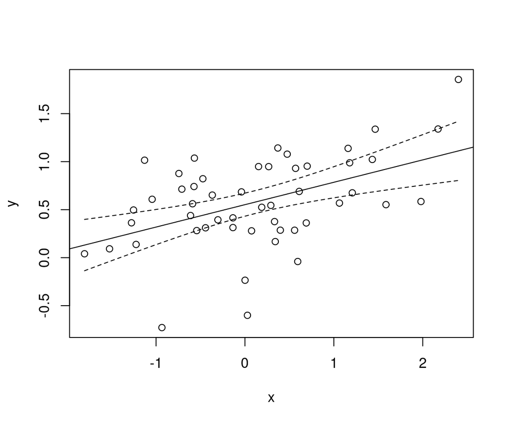

## Prediction intervals

Can find prediction intervals for a new observation with explanatory variable \(x\):

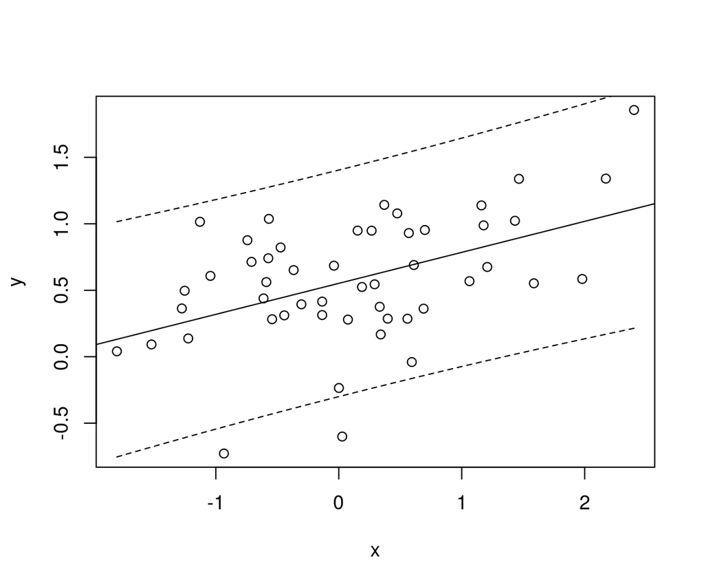

## Distribution of the estimator

It was possible to do all of these things because we knew the distribution of the estimator \((\hat \beta, \hat \sigma^2)\).

What happens when we move beyond the normal linear model? e.g.

- what if \(\epsilon_i\) is not normally distributed?
- what if our responses are not even continuous, e.g. \(Y_i \sim \text{Poisson}(\theta)\)?

Given any parametric model, we can estimate the parameters by maximum likelihood, but we don’t know the distribution of the MLE.

(See MATH3044 for some approximations as \(n\) gets large).

## Poisson example

If \(Y_i \sim \text{Poisson}(\theta)\), \(\hat \theta = \bar y\).

```r
set.seed(3)
```

```r
n <- 100
theta <- 0.2
y <- rpois(n, theta)
theta_hat <- mean(y)
theta_hat
```

```
## [1] 0.17
```

How should we quantify the uncertainty in \(\hat \theta\)?

## Replicated datasets

If we had many independent datasets, we could easily approximate the distribution of the estimator, just by finding the estimate (e.g. MLE) for each one, and looking at the distribution of those estimates.

If we have datasets \(y^{(1)}, \ldots, y^{(B)}\), get estimates \(\hat \theta^{(1)}, \ldots, \hat \theta^{(B)}\), and use their empirical distribution to estimate the distribution of \(\hat \theta\).

In our Poisson example

```r
B <- 10000
datasets_rep <- replicate(B, rpois(n, theta))
estimates_rep <- colMeans(datasets_rep)
```

## Summaries of the distribution

```r
mean(estimates_rep)
```

```
## [1] 0.200254
```

```r
sd(estimates_rep)
```

```
## [1] 0.04480531
```

## The distribution of \(\hat \theta\)

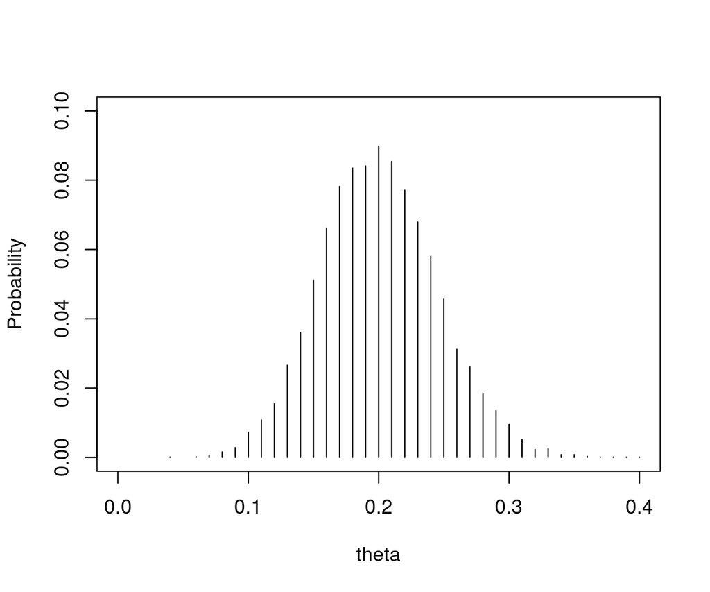

## Bootstrap

The problem is we **do not** have replicated datasets!

“Bootstrap” approaches involve generating “fake” replicated datasets \(y^{(1)}, \ldots, y^{(B)}\), then following the approach described above.

There are two options to generate the fake datasets:

1. “Parametric” bootstrap: generate \(y^{(j)}\) from the fitted model, e.g., \(y^{(j)}_i \sim \text{Poisson}(\hat \theta)\).
2. “Non-parametric” bootstrap: generate \(y^{(j)}\) by resampling (with replacement) \(n\) points from the original data \(\{y_1, \ldots, y_n\}\)

## Parametric bootstrap

```r
datasets_pboot <- replicate(B, rpois(n, theta_hat))
estimates_pboot <- colMeans(datasets_pboot)
```

We can get various summaries of the distribution:

```r
mean(estimates_pboot)
```

```
## [1] 0.170299
```

```r
sd(estimates_pboot)
```

```
## [1] 0.04149112
```

## Estimating the distribution of \(\hat \theta\)

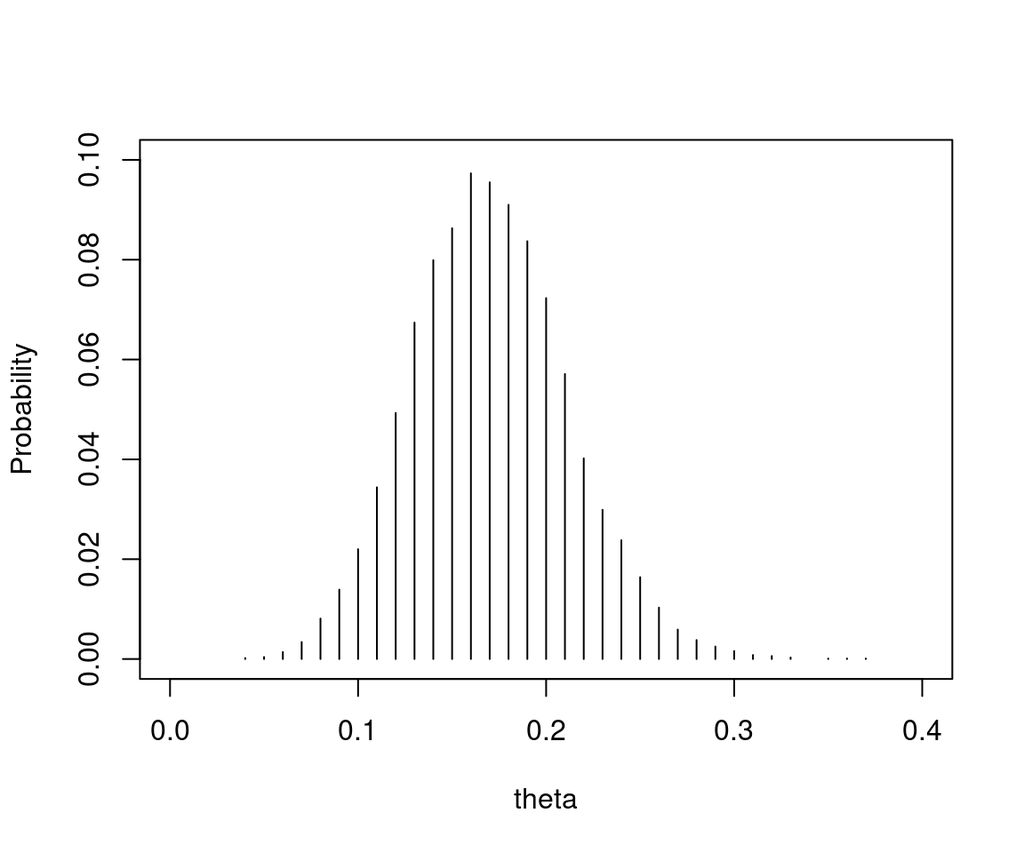

## Estimating the distribution of \(\hat \theta\)

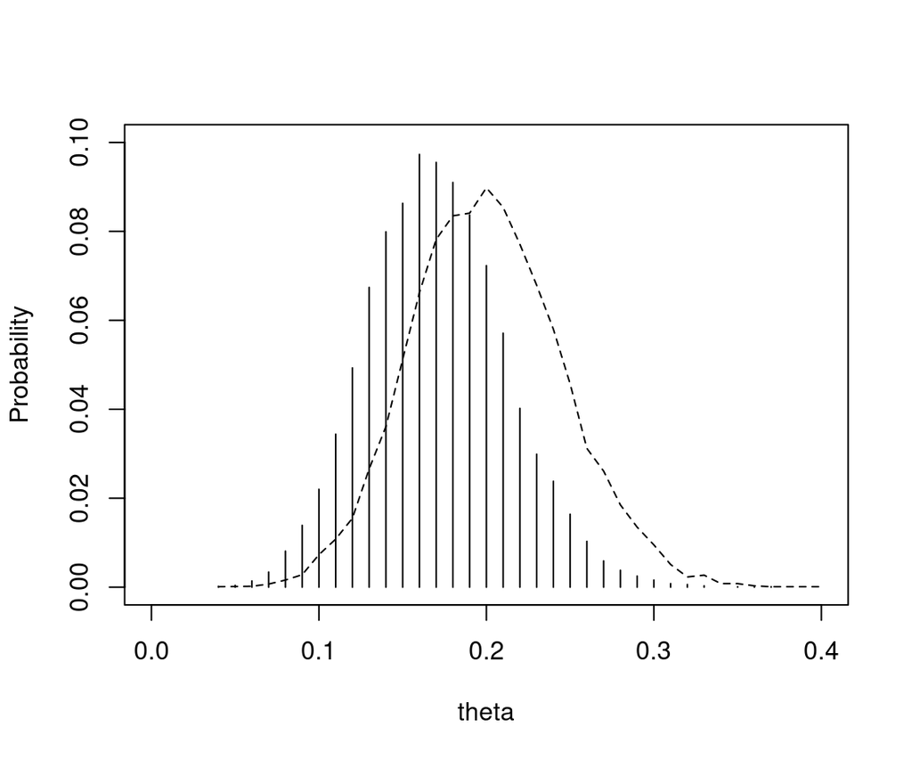

(dashed line shows true distribution)

## Non-parametric bootstrap

```r
datasets_npboot <- replicate(B, sample(y, n, replace = TRUE))
estimates_npboot <- colMeans(datasets_npboot)
```

We can get various summaries of the distribution:

```r
mean(estimates_npboot)
```

```
## [1] 0.170709
```

```r
sd(estimates_npboot)
```

```
## [1] 0.04086703
```

## Estimating the distribution of \(\hat \theta\)

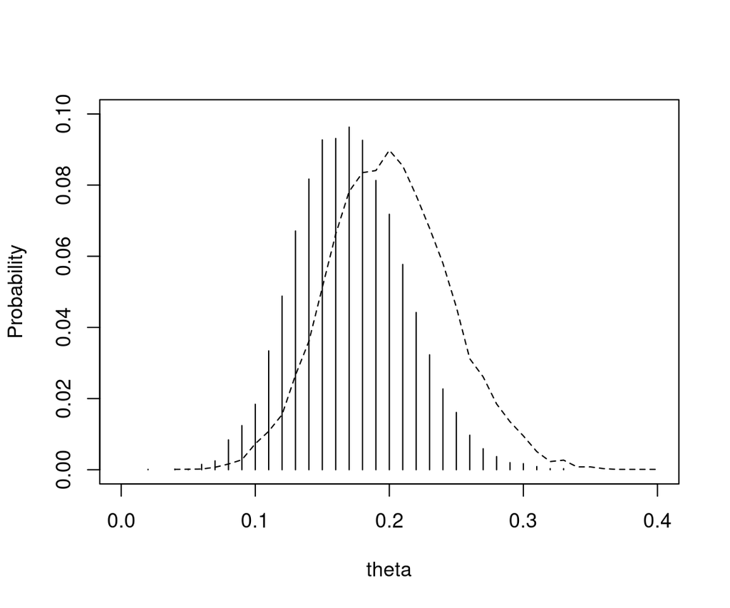

(dashed line shows true distribution)

## Parametric vs. non-parametric bootstrap

The parametric bootstrap is more reliant on our model being correct. If our model is incorrect, then datasets generated by the parametric bootstrap will **not** look like replicates from the true data generating process.

The non-parametric bootstrap does not use the model to generate the fake datasets, so is more “robust” to that model being misspecified.

Sometimes the non-parametric bootstrap is referred to as the bootstrap (as in ISLR).

## Model selection

How can we choose between various candidate models for our data?

e.g. should we use a straight line in a linear model, or a higher order polynomial?

```r
mod1 <- lm(y ~ x)
mod2 <- lm(y ~ poly(x, 2))
mod3 <- lm(y ~ poly(x, 3))
```

## Three possible linear models

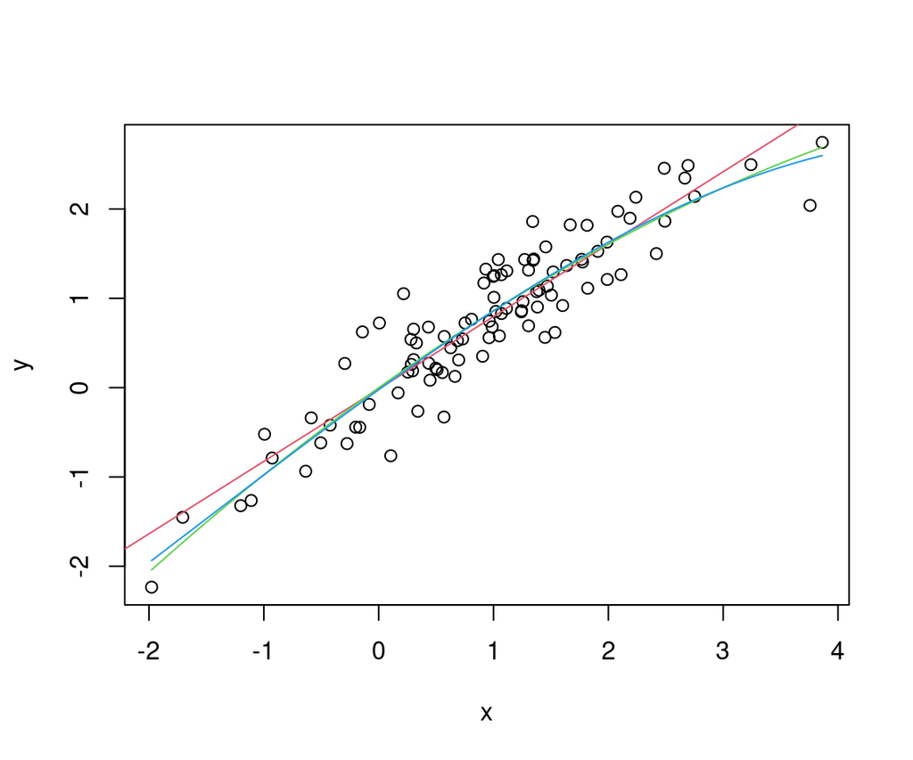

## Measuring fit to data

We can use the mean square error \(\frac{1}{n} \sum_{i=1}^n (y_i - \hat y_i)^2\) to see how well the model fits the data.

```r
mse1 <- mean((y - fitted(mod1))^2)
mse2 <- mean((y - fitted(mod2))^2)
mse3 <- mean((y - fitted(mod3))^2)
c(mse1, mse2, mse3)
```

```
## [1] 0.1309476 0.1204452 0.1199367
```

The models are nested, so the most complicated model will **always** fit most closely to the data. This does **not** mean it is a better model: we could be **overfitting** to noise in the data!

## Validation sets

We could avoid overfitting by keeping some part of the data as a “validation” set, and not using that part of the data for fitting.

e.g. we could take 10 of our data points out of the training data, and use them for validation.

```r
ids_validation <- sample(1:n, 10)
data_full <- data.frame(y = y, x = x)
data_validation <- data_full[ids_validation, ]
data_train <- data_full[-ids_validation, ]
```

## Validation sets

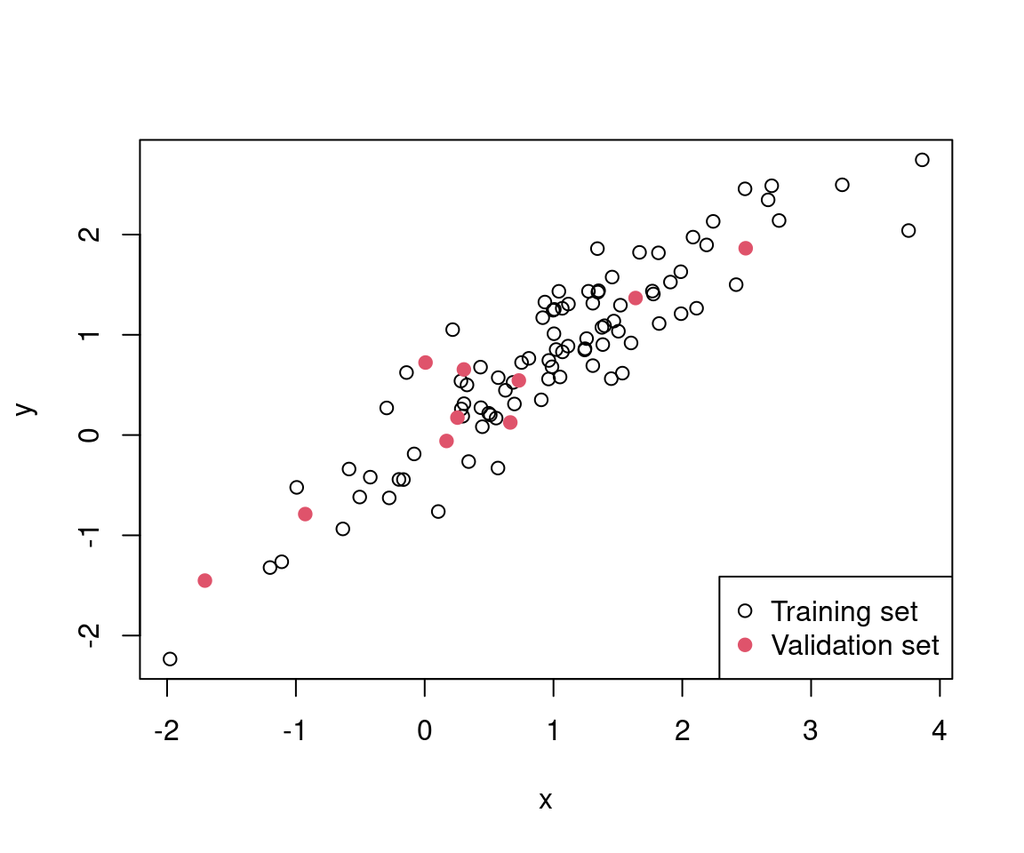

## Fitting to the training data

```r
mod1_train <- lm(y ~ x, data = data_train)
mod2_train <- lm(y ~ poly(x, 2), data = data_train)
mod3_train <- lm(y ~ poly(x, 3), data = data_train)
```

## Fitting to the training data

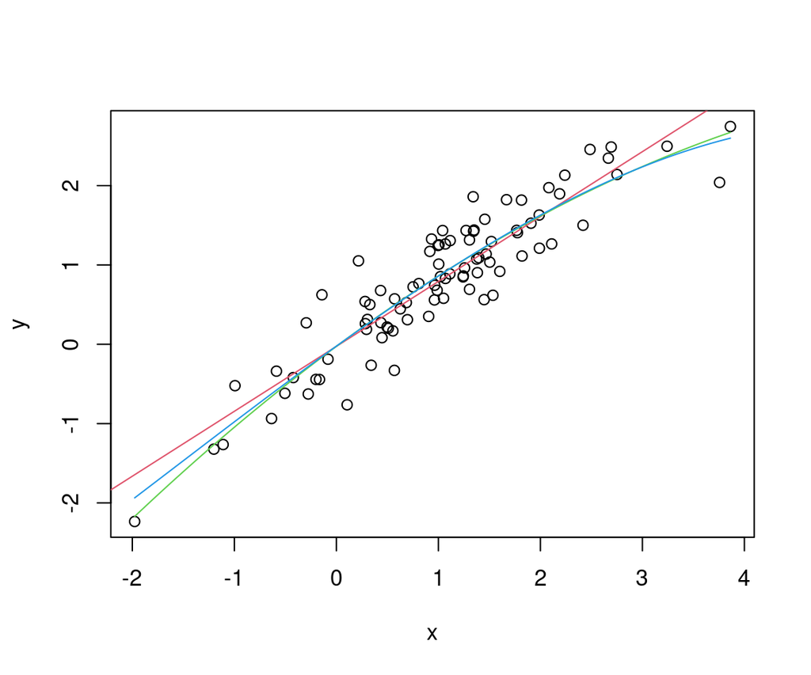

## Assessing model fit on the validation set

We can then assess model fit on the validation set.

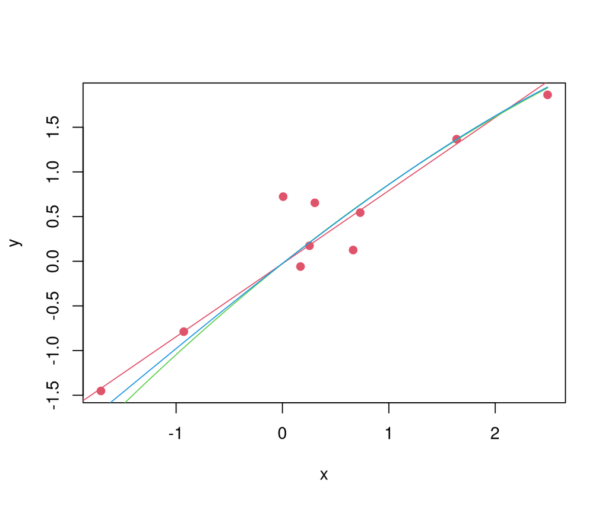

## Assessing model fit on the validation set

We can then assess model fit on the validation set.

```r
y_validation <- data_validation$y
y_hat_1 <- predict(mod1_train, newdata = data_validation)
y_hat_2 <- predict(mod2_train, newdata = data_validation)
y_hat_3 <- predict(mod3_train, newdata = data_validation)

mse1v <- mean((y - y_hat_1)^2)
mse2v <- mean((y - y_hat_2)^2)
mse3v <- mean((y - y_hat_3)^2)
c(mse1v, mse2v, mse3v)
```

```
## [1] 1.764458 1.957373 1.941913
```

## Problems with the validation set approach

Increasing the size of the validation set reduces the size of the training set, so the variance of the estimator will increase.

Reducing the size of the validation set increases the variability in our assessment of the models: repeating with different can lead to very different results.

Idea: to reduce this variability in our assessment of models, repeat the same process many times and average the results.

## Cross Validation (CV)

Repeat the same process many times:

1. Take a new validation set from the data
2. Fit the model to the remaining training data (everything not included in the validation set).
3. Calculate a measure of fit (e.g. mean squared error) of the model to the validation set.

The CV criterion is the average of the measures of fit from each of these validation sets.

## Leave-One-Out Cross Validation (LOOCV)

A simple and commonly used special case of this is Leave-One-Out Cross Validation, where we use all possible validation sets of size one.

For \(i = 1, \ldots, n\):

1. Fit the model to \(y_{-i}\), the data with the \(i\)th entry removed.
2. Calculate a measure of fit of the model \(m_i\) to \(y_i\), e.g. the squared error \(m_i = (y_i - \hat y_i)^2\)

Take the average of the measures of fit from each validation set \(\text{CV} = \frac{1}{n} \sum_{i=1}^n m_i\).

## Cross validation in the linear model example

```r
loocv_contrib_i <- function(i, mod) {
    data_minus_i <- data_full[-i, ]
    mod_minus_i <- lm(formula(mod), data = data_minus_i)
    data_i <- data_full[i, ]
    y_i <- data_i$y
    y_i_hat <- predict(mod_minus_i, newdata = data_i)
    (y_i - y_i_hat)^2
}

loocv <- function(mod) {
    mean(sapply(1:n, loocv_contrib_i, mod = mod))
}

c(loocv(mod1), loocv(mod2), loocv(mod3))
```

```
## [1] 0.1377381 0.1282445 0.1325701
```

## Variants of Cross Validation

Different variants of CV use different subsets of the data for validation sets.

See Section 5.1.3 and 5.1.4 of ISLR.

## Conclusion

We have looked at two resampling methods, the (non-parametric) bootstrap and cross validation.

Resampling methods can take a long time to run, particularly if it takes a fairly long time to estimate the parameter on each dataset.

More detail is available in Chapter 5 of ISLR.

See blackboard for some suggested exercises to try.